# Optimal Treatment Analysis

## Outcome Variable

**Outcome Variable:** whz

## Predictor Variables

**Intervention Variable:** fage

**Adjustment Set:**

- arm
- W_mage
- meducyrs
- feducyrs
- W_mhtcm
- W_mwtkg
- W_mbmi
- W_fhtcm
- single
- brthmon
- delta_W_mage
- delta_meducyrs
- delta_feducyrs
- delta_W_mhtcm
- delta_W_mwtkg
- delta_W_mbmi
- delta_W_fhtcm
- delta_single
- delta_brthmon

## Stratifying Variables

The analysis was stratified on these variable(s):

- agecat
- studyid
- country

## Data Summary

| agecat | studyid | country | fage | n_cell | n |
| --- | --- | --- | --- | --- | --- |
| Birth | ki0047075b-MAL-ED | BANGLADESH | >=38 | 65 | 140 |
| Birth | ki0047075b-MAL-ED | BANGLADESH | <32 | 25 | 140 |
| Birth | ki0047075b-MAL-ED | BANGLADESH | [32-38) | 50 | 140 |
| Birth | ki0047075b-MAL-ED | BRAZIL | >=38 | 25 | 65 |
| Birth | ki0047075b-MAL-ED | BRAZIL | <32 | 16 | 65 |
| Birth | ki0047075b-MAL-ED | BRAZIL | [32-38) | 24 | 65 |
| Birth | ki0047075b-MAL-ED | INDIA | >=38 | 26 | 128 |
| Birth | ki0047075b-MAL-ED | INDIA | <32 | 43 | 128 |
| Birth | ki0047075b-MAL-ED | INDIA | [32-38) | 59 | 128 |
| Birth | ki0047075b-MAL-ED | NEPAL | >=38 | 13 | 59 |
| Birth | ki0047075b-MAL-ED | NEPAL | <32 | 9 | 59 |
| Birth | ki0047075b-MAL-ED | NEPAL | [32-38) | 37 | 59 |
| Birth | ki0047075b-MAL-ED | PERU | >=38 | 27 | 78 |
| Birth | ki0047075b-MAL-ED | PERU | <32 | 26 | 78 |
| Birth | ki0047075b-MAL-ED | PERU | [32-38) | 25 | 78 |
| Birth | ki0047075b-MAL-ED | SOUTH AFRICA | >=38 | 52 | 75 |
| Birth | ki0047075b-MAL-ED | SOUTH AFRICA | <32 | 8 | 75 |
| Birth | ki0047075b-MAL-ED | SOUTH AFRICA | [32-38) | 15 | 75 |
| Birth | ki0047075b-MAL-ED | TANZANIA, UNITED REPUBLIC OF | >=38 | 20 | 44 |
| Birth | ki0047075b-MAL-ED | TANZANIA, UNITED REPUBLIC OF | <32 | 6 | 44 |
| Birth | ki0047075b-MAL-ED | TANZANIA, UNITED REPUBLIC OF | [32-38) | 18 | 44 |
| Birth | ki1000304b-SAS-CompFeed | INDIA | >=38 | 1 | 61 |
| Birth | ki1000304b-SAS-CompFeed | INDIA | <32 | 51 | 61 |
| Birth | ki1000304b-SAS-CompFeed | INDIA | [32-38) | 9 | 61 |
| Birth | ki1119695-PROBIT | BELARUS | >=38 | 298 | 6485 |
| Birth | ki1119695-PROBIT | BELARUS | <32 | 5164 | 6485 |
| Birth | ki1119695-PROBIT | BELARUS | [32-38) | 1023 | 6485 |
| Birth | ki1135781-COHORTS | GUATEMALA | >=38 | 107 | 362 |
| Birth | ki1135781-COHORTS | GUATEMALA | <32 | 171 | 362 |
| Birth | ki1135781-COHORTS | GUATEMALA | [32-38) | 84 | 362 |

[output cut: 75 more lines]

The following strata were considered:

- agecat: 24 months, studyid: ki0047075b-MAL-ED, country: BANGLADESH
- agecat: 24 months, studyid: ki0047075b-MAL-ED, country: BRAZIL
- agecat: 24 months, studyid: ki0047075b-MAL-ED, country: INDIA
- agecat: 24 months, studyid: ki0047075b-MAL-ED, country: NEPAL
- agecat: 24 months, studyid: ki0047075b-MAL-ED, country: PERU
- agecat: 24 months, studyid: ki0047075b-MAL-ED, country: SOUTH AFRICA
- agecat: 24 months, studyid: ki0047075b-MAL-ED, country: TANZANIA, UNITED REPUBLIC OF
- agecat: 24 months, studyid: ki1119695-PROBIT, country: BELARUS
- agecat: 24 months, studyid: ki1135781-COHORTS, country: GUATEMALA
- agecat: 24 months, studyid: ki1135781-COHORTS, country: PHILIPPINES
- agecat: 24 months, studyid: ki1148112-LCNI-5, country: MALAWI
- agecat: 6 months, studyid: ki0047075b-MAL-ED, country: BANGLADESH
- agecat: 6 months, studyid: ki0047075b-MAL-ED, country: BRAZIL
- agecat: 6 months, studyid: ki0047075b-MAL-ED, country: INDIA
- agecat: 6 months, studyid: ki0047075b-MAL-ED, country: NEPAL
- agecat: 6 months, studyid: ki0047075b-MAL-ED, country: PERU
- agecat: 6 months, studyid: ki0047075b-MAL-ED, country: SOUTH AFRICA
- agecat: 6 months, studyid: ki0047075b-MAL-ED, country: TANZANIA, UNITED REPUBLIC OF
- agecat: 6 months, studyid: ki1000304b-SAS-CompFeed, country: INDIA
- agecat: 6 months, studyid: ki1000304b-SAS-FoodSuppl, country: INDIA
- agecat: 6 months, studyid: ki1119695-PROBIT, country: BELARUS
- agecat: 6 months, studyid: ki1135781-COHORTS, country: GUATEMALA
- agecat: 6 months, studyid: ki1135781-COHORTS, country: PHILIPPINES
- agecat: 6 months, studyid: ki1148112-LCNI-5, country: MALAWI
- agecat: Birth, studyid: ki0047075b-MAL-ED, country: BANGLADESH
- agecat: Birth, studyid: ki0047075b-MAL-ED, country: BRAZIL
- agecat: Birth, studyid: ki0047075b-MAL-ED, country: INDIA
- agecat: Birth, studyid: ki0047075b-MAL-ED, country: NEPAL
- agecat: Birth, studyid: ki0047075b-MAL-ED, country: PERU
- agecat: Birth, studyid: ki0047075b-MAL-ED, country: SOUTH AFRICA
- agecat: Birth, studyid: ki0047075b-MAL-ED, country: TANZANIA, UNITED REPUBLIC OF
- agecat: Birth, studyid: ki1000304b-SAS-CompFeed, country: INDIA
- agecat: Birth, studyid: ki1119695-PROBIT, country: BELARUS
- agecat: Birth, studyid: ki1135781-COHORTS, country: GUATEMALA
- agecat: Birth, studyid: ki1135781-COHORTS, country: PHILIPPINES

### Dropped Strata

Some strata were dropped due to rare outcomes:

- agecat: Birth, studyid: ki1000304b-SAS-CompFeed, country: INDIA

## Methods Detail

We’re interested in the causal parameters $E[Y_a]$ for all values of $a \in \mathcal{A}$. These parameters represent the mean outcome if, possibly contrary to fact, we intervened to set all units to have $A=a$. Under the randomization and positivity assumptions, these are identified by the statistical parameters $\psi_a=E_W[E_{Y|A,W}(Y|A=a,W)]$. In addition, we’re interested in the mean of $Y$, $E[Y]$ under no intervention (the observed mean). We will estimate these parameters by using SuperLearner to fit the relevant likelihood factors – $E_{Y|A,W}(Y|A=a,W)$ and $p(A=a|W)$, and then updating our likelihood fit using a joint TMLE.

For unadjusted analyses ($W=\{\}$), initial likelihoods were estimated using Lrnr_glm to estimate the simple $E(Y|A)$ and Lrnr_mean to estimate $p(A)$. For adjusted analyses, a small library containing Lrnr_glmnet, Lrnr_xgboost, and Lrnr_mean was used.

Having estimated these parameters, we will then use the delta method to estimate relative risks and attributable risks relative to a prespecified baseline level of $A$.

# Results Detail

## Results Plots

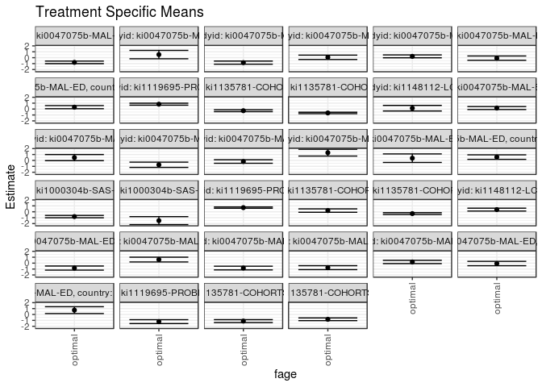

## Results Table

### Parameter: TSM

| agecat | studyid | country | intervention_level | baseline_level | estimate | ci_lower | ci_upper |
| --- | --- | --- | --- | --- | --- | --- | --- |
| Birth | ki0047075b-MAL-ED | BANGLADESH | optimal | observed | -0.8375582 | -1.1863937 | -0.4887228 |
| Birth | ki0047075b-MAL-ED | BRAZIL | optimal | observed | 0.6011428 | 0.1986286 | 1.0036569 |
| Birth | ki0047075b-MAL-ED | INDIA | optimal | observed | -0.8326970 | -1.1441498 | -0.5212442 |
| Birth | ki0047075b-MAL-ED | NEPAL | optimal | observed | -0.7678464 | -1.1017633 | -0.4339295 |
| Birth | ki0047075b-MAL-ED | PERU | optimal | observed | 0.1990462 | -0.0787354 | 0.4768278 |
| Birth | ki0047075b-MAL-ED | SOUTH AFRICA | optimal | observed | -0.0698006 | -0.4392437 | 0.2996424 |
| Birth | ki0047075b-MAL-ED | TANZANIA, UNITED REPUBLIC OF | optimal | observed | 0.7341582 | 0.1539031 | 1.3144132 |
| Birth | ki1119695-PROBIT | BELARUS | optimal | observed | -1.2078713 | -1.5379772 | -0.8777655 |
| Birth | ki1135781-COHORTS | GUATEMALA | optimal | observed | -1.1197942 | -1.3658852 | -0.8737032 |
| Birth | ki1135781-COHORTS | PHILIPPINES | optimal | observed | -0.8143984 | -1.0433349 | -0.5854619 |
| 6 months | ki0047075b-MAL-ED | BANGLADESH | optimal | observed | 0.1749034 | -0.0775560 | 0.4273627 |
| 6 months | ki0047075b-MAL-ED | BRAZIL | optimal | observed | 0.4778325 | -0.0400634 | 0.9957284 |
| 6 months | ki0047075b-MAL-ED | INDIA | optimal | observed | -0.7367117 | -1.1816624 | -0.2917609 |
| 6 months | ki0047075b-MAL-ED | NEPAL | optimal | observed | -0.1846334 | -0.4837714 | 0.1145045 |
| 6 months | ki0047075b-MAL-ED | PERU | optimal | observed | 1.3094769 | 0.7367989 | 1.8821550 |
| 6 months | ki0047075b-MAL-ED | SOUTH AFRICA | optimal | observed | 0.3777189 | -0.3472583 | 1.1026961 |
| 6 months | ki0047075b-MAL-ED | TANZANIA, UNITED REPUBLIC OF | optimal | observed | 0.5654100 | 0.1854459 | 0.9453741 |
| 6 months | ki1000304b-SAS-CompFeed | INDIA | optimal | observed | -0.8131638 | -1.0145982 | -0.6117294 |
| 6 months | ki1000304b-SAS-FoodSuppl | INDIA | optimal | observed | -1.4969042 | -2.1726614 | -0.8211470 |
| 6 months | ki1119695-PROBIT | BELARUS | optimal | observed | 0.7016717 | 0.5924459 | 0.8108975 |
| 6 months | ki1135781-COHORTS | GUATEMALA | optimal | observed | 0.2034015 | -0.0851073 | 0.4919104 |
| 6 months | ki1135781-COHORTS | PHILIPPINES | optimal | observed | -0.3102141 | -0.4667921 | -0.1536361 |
| 6 months | ki1148112-LCNI-5 | MALAWI | optimal | observed | 0.3666528 | 0.1234670 | 0.6098387 |
| 24 months | ki0047075b-MAL-ED | BANGLADESH | optimal | observed | -0.7870973 | -1.0013864 | -0.5728082 |
| 24 months | ki0047075b-MAL-ED | BRAZIL | optimal | observed | 0.5302394 | -0.1811181 | 1.2415970 |
| 24 months | ki0047075b-MAL-ED | INDIA | optimal | observed | -0.8323967 | -1.0980541 | -0.5667393 |
| 24 months | ki0047075b-MAL-ED | NEPAL | optimal | observed | 0.0727300 | -0.2957847 | 0.4412446 |
| 24 months | ki0047075b-MAL-ED | PERU | optimal | observed | 0.2312336 | -0.0103794 | 0.4728467 |
| 24 months | ki0047075b-MAL-ED | SOUTH AFRICA | optimal | observed | -0.0720236 | -0.4364952 | 0.2924481 |
| 24 months | ki0047075b-MAL-ED | TANZANIA, UNITED REPUBLIC OF | optimal | observed | 0.3258744 | 0.0613577 | 0.5903912 |
| 24 months | ki1119695-PROBIT | BELARUS | optimal | observed | 0.8272145 | 0.6602266 | 0.9942023 |
| 24 months | ki1135781-COHORTS | GUATEMALA | optimal | observed | -0.2753520 | -0.4389452 | -0.1117588 |
| 24 months | ki1135781-COHORTS | PHILIPPINES | optimal | observed | -0.6564785 | -0.7780955 | -0.5348614 |
| 24 months | ki1148112-LCNI-5 | MALAWI | optimal | observed | 0.1478947 | -0.3241263 | 0.6199158 |

### Parameter: E(Y)

| agecat | studyid | country | intervention_level | baseline_level | estimate | ci_lower | ci_upper |
| --- | --- | --- | --- | --- | --- | --- | --- |
| Birth | ki0047075b-MAL-ED | BANGLADESH | observed | observed | -1.0282143 | -1.1991720 | -0.8572566 |
| Birth | ki0047075b-MAL-ED | BRAZIL | observed | observed | 0.4923077 | 0.1981785 | 0.7864369 |
| Birth | ki0047075b-MAL-ED | INDIA | observed | observed | -1.1116406 | -1.2776411 | -0.9456401 |
| Birth | ki0047075b-MAL-ED | NEPAL | observed | observed | -0.7467797 | -0.9945570 | -0.4990023 |
| Birth | ki0047075b-MAL-ED | PERU | observed | observed | -0.0162821 | -0.2170871 | 0.1845230 |
| Birth | ki0047075b-MAL-ED | SOUTH AFRICA | observed | observed | 0.1318667 | -0.1289649 | 0.3926982 |
| Birth | ki0047075b-MAL-ED | TANZANIA, UNITED REPUBLIC OF | observed | observed | 0.7968182 | 0.4398380 | 1.1537983 |
| Birth | ki1119695-PROBIT | BELARUS | observed | observed | -1.1836484 | -1.5179968 | -0.8493001 |
| Birth | ki1135781-COHORTS | GUATEMALA | observed | observed | -1.2578729 | -1.4000444 | -1.1157015 |
| Birth | ki1135781-COHORTS | PHILIPPINES | observed | observed | -0.7309760 | -0.7780724 | -0.6838797 |
| 6 months | ki0047075b-MAL-ED | BANGLADESH | observed | observed | -0.1977833 | -0.3606366 | -0.0349301 |
| 6 months | ki0047075b-MAL-ED | BRAZIL | observed | observed | 0.9393882 | 0.6572880 | 1.2214884 |
| 6 months | ki0047075b-MAL-ED | INDIA | observed | observed | -0.7206832 | -0.8692329 | -0.5721336 |
| 6 months | ki0047075b-MAL-ED | NEPAL | observed | observed | 0.1778270 | -0.0614697 | 0.4171237 |
| 6 months | ki0047075b-MAL-ED | PERU | observed | observed | 1.0140361 | 0.7785203 | 1.2495520 |
| 6 months | ki0047075b-MAL-ED | SOUTH AFRICA | observed | observed | 0.5153558 | 0.2512666 | 0.7794450 |
| 6 months | ki0047075b-MAL-ED | TANZANIA, UNITED REPUBLIC OF | observed | observed | 0.5034500 | 0.2959923 | 0.7109077 |
| 6 months | ki1000304b-SAS-CompFeed | INDIA | observed | observed | -0.7967726 | -0.9975479 | -0.5959974 |
| 6 months | ki1000304b-SAS-FoodSuppl | INDIA | observed | observed | -1.1301031 | -1.3613760 | -0.8988302 |
| 6 months | ki1119695-PROBIT | BELARUS | observed | observed | 0.5809777 | 0.5017906 | 0.6601649 |
| 6 months | ki1135781-COHORTS | GUATEMALA | observed | observed | 0.0505393 | -0.0593404 | 0.1604190 |
| 6 months | ki1135781-COHORTS | PHILIPPINES | observed | observed | -0.2878032 | -0.3296319 | -0.2459745 |
| 6 months | ki1148112-LCNI-5 | MALAWI | observed | observed | 0.5058491 | 0.3128980 | 0.6988001 |
| 24 months | ki0047075b-MAL-ED | BANGLADESH | observed | observed | -0.8861589 | -1.0281048 | -0.7442131 |
| 24 months | ki0047075b-MAL-ED | BRAZIL | observed | observed | 0.5441139 | 0.2074310 | 0.8807969 |
| 24 months | ki0047075b-MAL-ED | INDIA | observed | observed | -0.8977019 | -1.0295625 | -0.7658412 |
| 24 months | ki0047075b-MAL-ED | NEPAL | observed | observed | -0.2838608 | -0.4798646 | -0.0878569 |
| 24 months | ki0047075b-MAL-ED | PERU | observed | observed | 0.1203797 | -0.0839887 | 0.3247482 |
| 24 months | ki0047075b-MAL-ED | SOUTH AFRICA | observed | observed | 0.4538202 | 0.2465091 | 0.6611314 |
| 24 months | ki0047075b-MAL-ED | TANZANIA, UNITED REPUBLIC OF | observed | observed | 0.0766500 | -0.1115307 | 0.2648307 |
| 24 months | ki1119695-PROBIT | BELARUS | observed | observed | 0.8058559 | 0.6588680 | 0.9528438 |
| 24 months | ki1135781-COHORTS | GUATEMALA | observed | observed | -0.5407800 | -0.6184091 | -0.4631509 |
| 24 months | ki1135781-COHORTS | PHILIPPINES | observed | observed | -0.6087584 | -0.6459824 | -0.5715345 |
| 24 months | ki1148112-LCNI-5 | MALAWI | observed | observed | -0.1982432 | -0.4246666 | 0.0281801 |

### Parameter: PAR

| agecat | studyid | country | intervention_level | baseline_level | estimate | ci_lower | ci_upper |
| --- | --- | --- | --- | --- | --- | --- | --- |
| Birth | ki0047075b-MAL-ED | BANGLADESH | optimal | observed | -0.1906560 | -0.4924324 | 0.1111203 |
| Birth | ki0047075b-MAL-ED | BRAZIL | optimal | observed | -0.1088351 | -0.5004139 | 0.2827437 |
| Birth | ki0047075b-MAL-ED | INDIA | optimal | observed | -0.2789436 | -0.5528611 | -0.0050261 |
| Birth | ki0047075b-MAL-ED | NEPAL | optimal | observed | 0.0210668 | -0.1802649 | 0.2223984 |
| Birth | ki0047075b-MAL-ED | PERU | optimal | observed | -0.2153283 | -0.4678394 | 0.0371828 |
| Birth | ki0047075b-MAL-ED | SOUTH AFRICA | optimal | observed | 0.2016673 | -0.0678969 | 0.4712315 |
| Birth | ki0047075b-MAL-ED | TANZANIA, UNITED REPUBLIC OF | optimal | observed | 0.0626600 | -0.5303934 | 0.6557134 |
| Birth | ki1119695-PROBIT | BELARUS | optimal | observed | 0.0242229 | -0.0590560 | 0.1075018 |
| Birth | ki1135781-COHORTS | GUATEMALA | optimal | observed | -0.1380787 | -0.3501864 | 0.0740289 |
| Birth | ki1135781-COHORTS | PHILIPPINES | optimal | observed | 0.0834223 | -0.1397176 | 0.3065622 |
| 6 months | ki0047075b-MAL-ED | BANGLADESH | optimal | observed | -0.3726867 | -0.6100532 | -0.1353202 |
| 6 months | ki0047075b-MAL-ED | BRAZIL | optimal | observed | 0.4615557 | 0.0348608 | 0.8882505 |
| 6 months | ki0047075b-MAL-ED | INDIA | optimal | observed | 0.0160285 | -0.3937590 | 0.4258159 |
| 6 months | ki0047075b-MAL-ED | NEPAL | optimal | observed | 0.3624605 | 0.0927950 | 0.6321259 |
| 6 months | ki0047075b-MAL-ED | PERU | optimal | observed | -0.2954408 | -0.7508883 | 0.1600067 |
| 6 months | ki0047075b-MAL-ED | SOUTH AFRICA | optimal | observed | 0.1376369 | -0.4872815 | 0.7625554 |
| 6 months | ki0047075b-MAL-ED | TANZANIA, UNITED REPUBLIC OF | optimal | observed | -0.0619600 | -0.4221696 | 0.2982496 |
| 6 months | ki1000304b-SAS-CompFeed | INDIA | optimal | observed | 0.0163912 | -0.0148577 | 0.0476400 |
| 6 months | ki1000304b-SAS-FoodSuppl | INDIA | optimal | observed | 0.3668011 | -0.2403438 | 0.9739460 |
| 6 months | ki1119695-PROBIT | BELARUS | optimal | observed | -0.1206940 | -0.2151599 | -0.0262281 |
| 6 months | ki1135781-COHORTS | GUATEMALA | optimal | observed | -0.1528622 | -0.4161320 | 0.1104077 |
| 6 months | ki1135781-COHORTS | PHILIPPINES | optimal | observed | 0.0224109 | -0.1303497 | 0.1751714 |
| 6 months | ki1148112-LCNI-5 | MALAWI | optimal | observed | 0.1391962 | -0.1086159 | 0.3870084 |
| 24 months | ki0047075b-MAL-ED | BANGLADESH | optimal | observed | -0.0990616 | -0.2799373 | 0.0818141 |
| 24 months | ki0047075b-MAL-ED | BRAZIL | optimal | observed | 0.0138745 | -0.6224994 | 0.6502484 |
| 24 months | ki0047075b-MAL-ED | INDIA | optimal | observed | -0.0653052 | -0.3249540 | 0.1943436 |
| 24 months | ki0047075b-MAL-ED | NEPAL | optimal | observed | -0.3565907 | -0.6758132 | -0.0373683 |
| 24 months | ki0047075b-MAL-ED | PERU | optimal | observed | -0.1108539 | -0.3492453 | 0.1275376 |
| 24 months | ki0047075b-MAL-ED | SOUTH AFRICA | optimal | observed | 0.5258438 | 0.1487291 | 0.9029584 |
| 24 months | ki0047075b-MAL-ED | TANZANIA, UNITED REPUBLIC OF | optimal | observed | -0.2492244 | -0.4465318 | -0.0519171 |
| 24 months | ki1119695-PROBIT | BELARUS | optimal | observed | -0.0213586 | -0.1523242 | 0.1096070 |
| 24 months | ki1135781-COHORTS | GUATEMALA | optimal | observed | -0.2654280 | -0.4203506 | -0.1105054 |
| 24 months | ki1135781-COHORTS | PHILIPPINES | optimal | observed | 0.0477201 | -0.0682192 | 0.1636593 |
| 24 months | ki1148112-LCNI-5 | MALAWI | optimal | observed | -0.3461380 | -0.7411536 | 0.0488776 |